# MT5763 Assignment 2

230031900

[Source code link](https://github.com/mt5763standrews/individual-assignment-2-evaberezovska)

# Introduction

In this report we analyse the relationship between profit, revenue, economic sector and employees of companies to predict future market value of the company. The data used was collected from the Fortune magazine list of largest American companies by revenue. According to [Fortune Wiki](https://en.wikipedia.org/wiki/Fortune_500), as of 2020, the list top 500 companies make around 2/3 of the United Stated GDP with approximately $14.2 trillion in revenue, $1.2 trillion in profits and $20.4 in total market value, and its revenues account for approximately 18% of the gross world product.Therefore, those companies make a crucial impact on the economy and exploring the relationship between the companies corresponding financial metrics is important to make relevant predictions. For the purposes of this analysis, we have conducted appropriate data wrangling. A linear model was used to analyse the data to explore those relationships. This analysis was limited to using a linear regression of economic sector, profits, assets and revenue as predictors to model the market value. It is likely possible to improve the model further using more predictors available in the dataset.

# Method

The data on financial metrics was collected by the Fortune magazine, listing the largest by revenue top 1000 companies in 2023 and top 500 companies in 2024. In our analysis we have chosen data for different years to be able to explore the financial metrics in dynamics. The fortune 2023 data contains 1000 observations of 31 variables. The fortune 2024 data contains 500 observations of 16 variables. In this analysis we will consider 14 variables:

- Company: Company Name
- State: The state in which the company headquarters is located.
- MarketCap: Market capitalization in dollars, share value multiplied by number of shares.
- Revenue: The revenue generated by the company in millions of dollars.
- Assets: The assets of the company in millions of dollars.
- Employees: The number of people employed by the company.
- FounderCEO: Is the founder of the company the CEO, boolean true or false.
- FemaleCEO: Is the CEO a woman, boolean true or false.
- Profits: The profit of the company in millions of dollars.
- Date: The end of the fiscal year, namely March 31 and corresponding year.
- RevenueEmployee: Revenue divided by the number of employees.
- ProfitMargin: Profit divided by Revenue.
- EconomicSector: Industrial sectors grouped into 4 economic sectors, labeled by numbers:
1. primary: is all companies whose IndustrialSector is Materials, Energy;
2. secondary: is all companies whose IndustrialSector is Motor Vehicles & Parts, Food, Beverages & Tobacco, Household Products, Industrials, Aerospace & Defense, Chemicals, Apparel, Engineering & Construction.
3. tertiary: is all companies whose IndustrialSector is Retailing, Health Care, Financials, Telecommunications, Food & Drug Stores, Transportation, Media, Hotels, Restaurants & Leisure, Wholesalers.
4. quaternary: is all companies whose IndustrialSector is Technology, Business Services.
- Year: Year when the data was collected.

**Data Wrangling**

*Fortune 2024 dataset*

The data was processed to clean it for the downstream analysis. In particular, the following operations were made:

- Selected and renamed 14 variables for data readability and relevancy for the analysis.
- Formatted numeric and boolean variables for data wrangling, exploration and modelling consistency.
- Grouped values of Industrial sector variable into four Economic sectors labeled by numbers 1-4 for more convenient data classification and comparisons.
- Created two new variables as ratios of profits, revenue and number of employees.

The results of the data wrangling outlined in Table 1.

Table 1: Fortune 2024 clean data

| Company | State | MarketCap | Revenue | Profits | Assets | Employees | FounderCEO | FemaleCEO | Date | RevenueEmployee | ProfitMargin | EconomicSector |
| --- | --- | --- | --- | --- | --- | --- | --- | --- | --- | --- | --- | --- |
| Walmart | AR | 484852.8 | 648125 | 15511 | 252399 | 2100000 | FALSE | FALSE | 2024-03-31 | 0.3086310 | 0.0239321 | 3 |
| Amazon | WA | 1873675.8 | 574785 | 30425 | 527854 | 1525000 | FALSE | FALSE | 2024-03-31 | 0.3769082 | 0.0529328 | 3 |
| Apple | CA | 2647973.8 | 383285 | 96995 | 352583 | 161000 | FALSE | FALSE | 2024-03-31 | 2.3806522 | 0.2530623 | 4 |
| UnitedHealth Group | MN | 456080.8 | 371622 | 22381 | 273720 | 440000 | FALSE | FALSE | 2024-03-31 | 0.8445955 | 0.0602252 | 3 |
| Berkshire Hathaway | NE | 908919.7 | 364482 | 96223 | 1069978 | 396500 | FALSE | FALSE | 2024-03-31 | 0.9192484 | 0.2639993 | 3 |
| CVS Health | RI | 100373.9 | 357776 | 8344 | 249728 | 259500 | FALSE | TRUE | 2024-03-31 | 1.3787129 | 0.0233219 | 3 |

*Fortune 2023 dataset*

The data was processed to clean it for the downstream analysis. In particular, the following operations were made:

- Selected and renamed 14 variables for data readability and relevancy for the analysis.
- Formatted numeric and boolean variables for data wrangling, exploration and modelling consistency.
- Grouped values of Industrial sector variable into four Economic sectors labeled by numbers 1-4 for more convenient data classification and comparisons.
- Created two new variables as ratios of profits, revenue and number of employees.
- Converted Profitable and Abs Profits columns to Profits.
- Ranked and selected top 500 out of 1000 companies by revenue to make this dataset of comparable size as fortune 2024 dataset. This is important to draw meaningful conclusions during data visual exploration.

The results of the data wrangling outlined in the Table 2.

Table 2: Fortune 2023 clean data

| Company | State | MarketCap | Revenue | Assets | Employees | FounderCEO | FemaleCEO | Profits | Date | RevenueEmployee | ProfitMargin | EconomicSector |
| --- | --- | --- | --- | --- | --- | --- | --- | --- | --- | --- | --- | --- |
| Walmart | AR | 397475 | 611289 | 243197 | 2100000 | FALSE | FALSE | 11680 | 2023-03-31 | 0.2910900 | 0.0191072 | 3 |
| Amazon | WA | 1058440 | 513983 | 462675 | 1541000 | FALSE | FALSE | -2722 | 2023-03-31 | 0.3335386 | -0.0052959 | 3 |
| Exxon Mobil | TX | 446424 | 413680 | 369067 | 62000 | FALSE | FALSE | 55740 | 2023-03-31 | 6.6722581 | 0.1347418 | 1 |
| Apple | CA | 2609039 | 394328 | 352755 | 164000 | FALSE | FALSE | 99803 | 2023-03-31 | 2.4044390 | 0.2530964 | 4 |
| UnitedHealth Group | MN | 440854 | 324162 | 245705 | 400000 | FALSE | FALSE | 20120 | 2023-03-31 | 0.8104050 | 0.0620677 | 3 |
| CVS Health | RI | 95422 | 322467 | 228275 | 259500 | FALSE | TRUE | 4149 | 2023-03-31 | 1.2426474 | 0.0128664 | 3 |

**Data visual exploration**

We have visually explored the relationships between market value, revenue, profits, CEO and economic sector for both fortune 2023 and 2024 datasets. Each visualisation shows the comparison between both years and provides insights on the variables and their dynamics.

First, we have explored the company revenue distribution between the two years. As shown in Figure 1. below, there is clearly a right-skewed distribution for both years with majority of companies placed at the lower end on the scale. We can note a few outliers at the right tail - those are the companies generating highest amount of revenues.

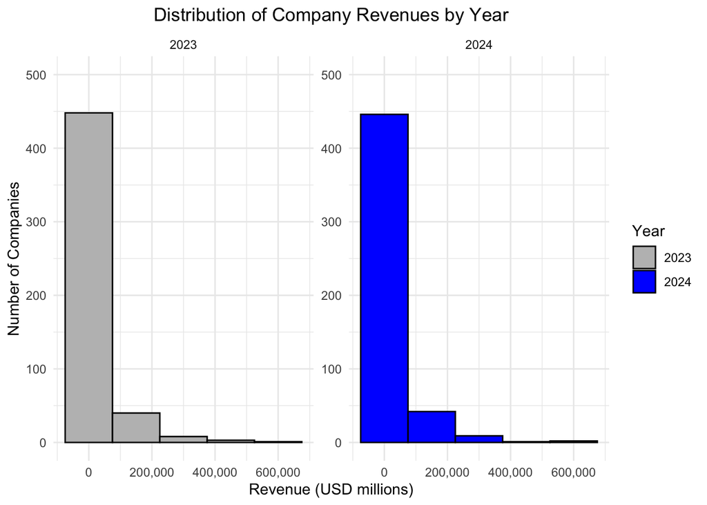

Figure 1: Distribution of Company Revenues by Year

Highest revenue generating companies for both years are shown in the Table 3. Their revenues amount to more than 400 000 USD millions.

Table 3: Fortune revenue outliers

| Company | Revenue | Profits | MarketCap | Employees |
| --- | --- | --- | --- | --- |
| Walmart | 611289 | 11680 | 397475.0 | 2100000 |
| Amazon | 513983 | -2722 | 1058440.0 | 1541000 |
| Exxon Mobil | 413680 | 55740 | 446424.0 | 62000 |
| Walmart | 648125 | 15511 | 484852.8 | 2100000 |
| Amazon | 574785 | 30425 | 1873675.8 | 1525000 |

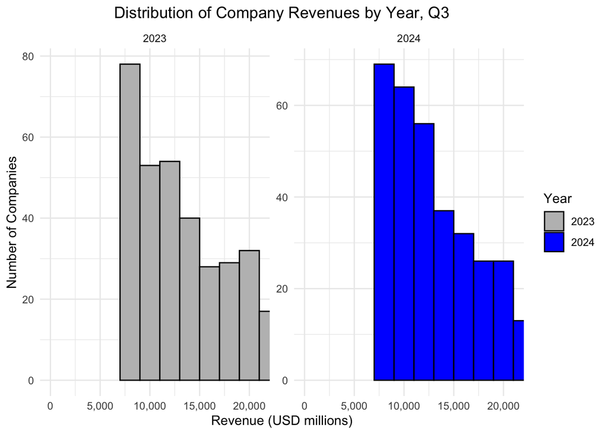

Figure 2: Distribution of Company Revenues by Year, Q3

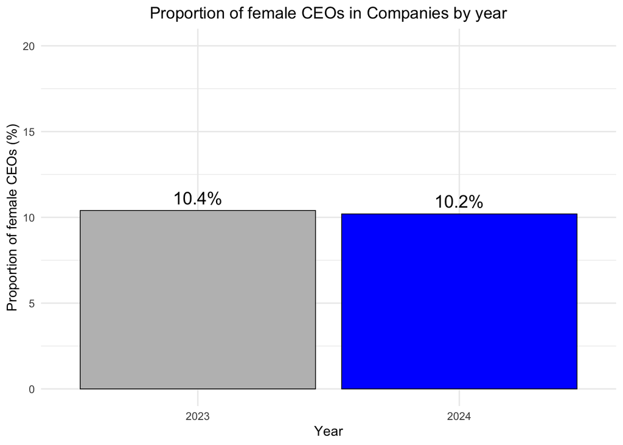

Figure 3: Proportion of female CEOs in Companies by year

Further, we have explored the association between the Profits as an assumed predictor and MarketCap - the market value estimation variable.

As can be seen in Figure 4, there is a positive correlation and linear relationship between both variables, suggesting that levels of profits are associated with market value. The trend line suggesting linear relationship is consistent across both years. The spread around the trend line indicates higher variability and can be an indicator of other factors that have association with market value. In 2024, some companies have visibly higher profits and market value, suggesting a possible growth or increase in profits for those companies.

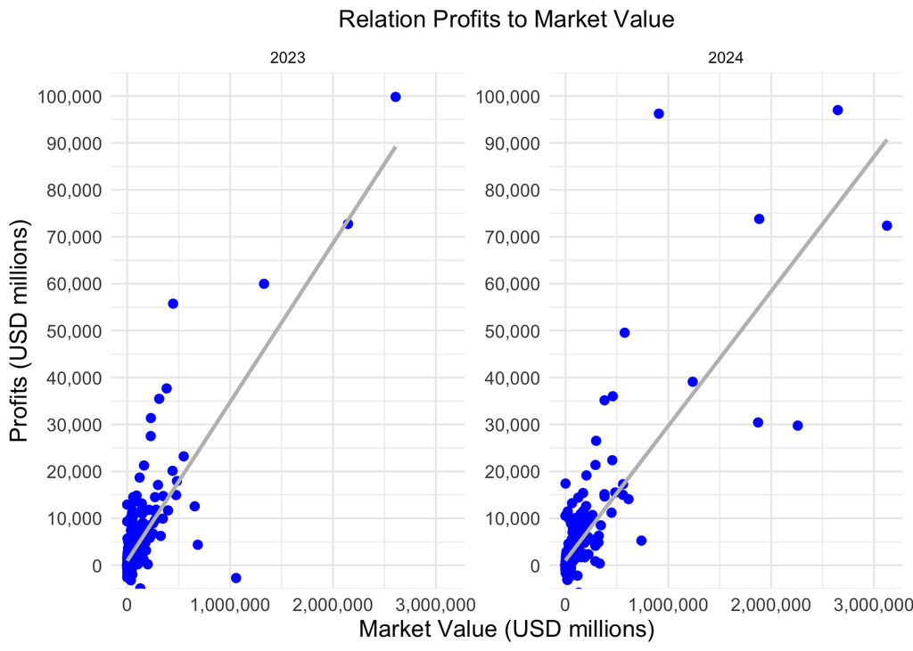

Figure 4: Relation Profits to Market Value

Next, we have explored how the number of people companies employ varies across different economic sectors. As seen in Figure 5, overall the number of employees slightly increased in 2024 in comparison to 2023. Namely, number of employees in sector one (primary) increased by nearly 4 %, in sector three (tertiary) increased by only 1 % and sector four (quaternary) increased the most by 7,5 %. Only sector two (secondary) had a slight decrease by 0.6 %. Increase in employment in the quaternary sector can indicate financial growth on that economic sector.

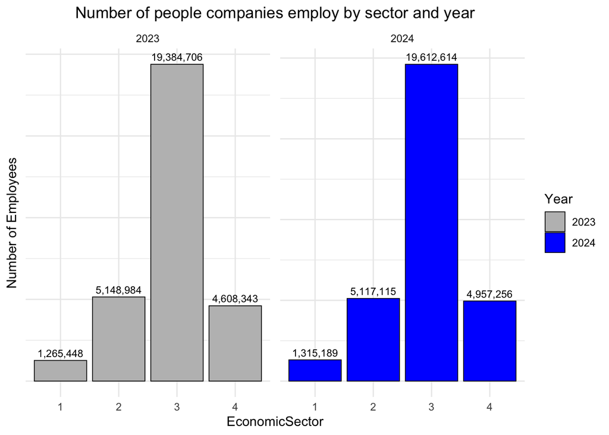

Figure 5: Number of people companies employ by sector and year

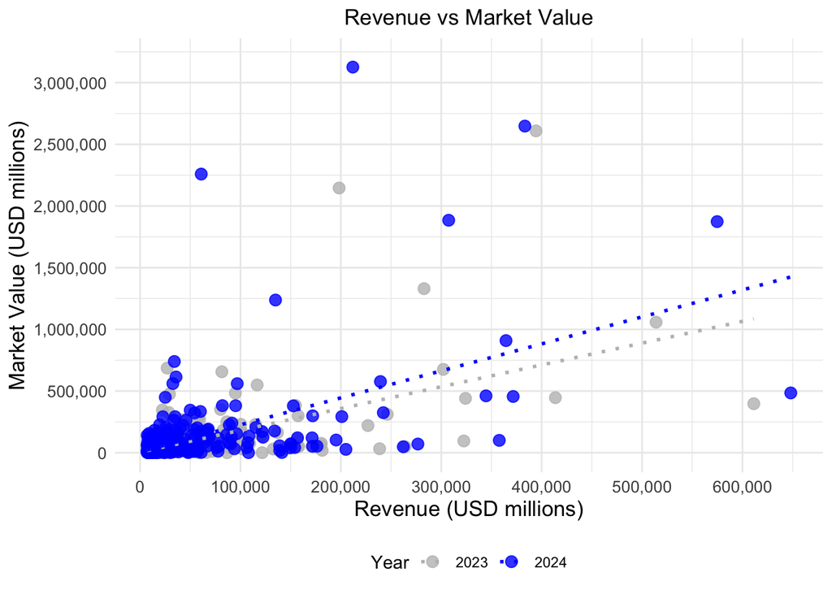

Figure 6: Revenue vs Market Value

Association between Assets and Market Value is weaker, as it can be seen in Figure 7, there is a positive but weak correlation between variables. Trend lines are quite flat but consistent for both years suggesting there is no strong association between the amount of assets and market value of the companies. High variablity spread across the trend line suggests that there are other factors having strong associations with the market value.

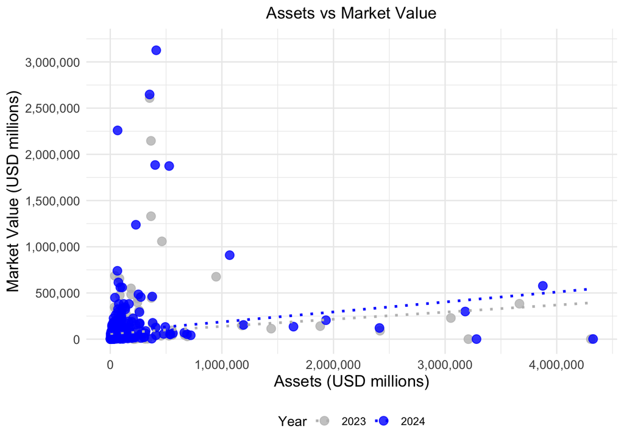

Figure 7: Assets vs Market Value

While Revenue and Assets have stronger positive correlation, as shown in Figure 8 and trend lines for both years demonstrate a similar relationship. Some companies in 2024 have higher positions indicating some outliers that can be possibly explained either by other factors that influence their assets despite relatively lower revenues or specific business strategy of those companies.

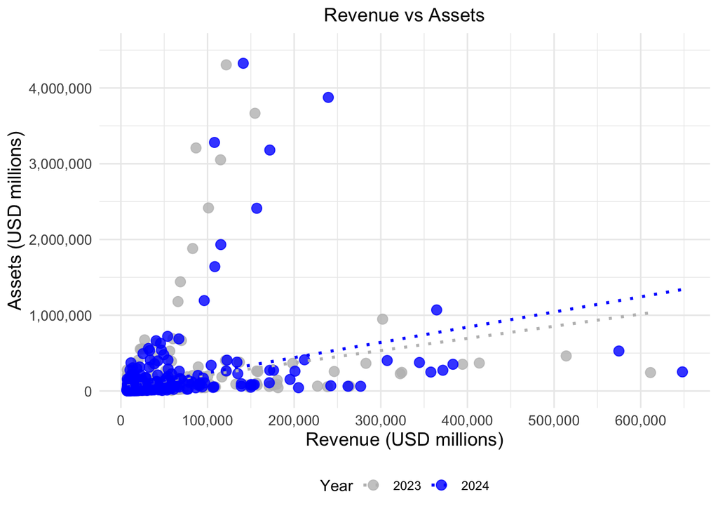

Figure 8: Revenue vs Assets

**Statistical modelling**

We fitted a linear model to predict the market value of the company using the variables economic sector, profits, assets and revenue as predictors. We fitted a linear model of natural log of MarketCap as the response variable. We fitted a natural log for the variables Assets and Revenues to normalize the distribution of skewed variables and improving model fit. The model fitted is described in Equation (1).

$$\begin{equation}
\log(MarketCap) = \beta_0 + \beta_1 EconomicSector + \beta_2 Profits + \beta_3 log(Assets) + \beta_4 log(Revenue)
\tag{1}
\end{equation}$$

# Results

*Linear model for Fortune 2023 dataset*

Linear model results for 2023 year as presented in the Table 4 below indicate that overall chosen predictors significantly affect the Market Value. The model explains approximately 44.93 % of the variance in log of MarketCap, and an adjusted R-squared 0.4423 suggesting a moderate fit. F-statistic is 63.78 and small p.value of less than 0.001 confirm that the linear model is statistically significant. Among the predictors, EconomicSector4 (quaternary) has the strongest positive relationship with the Market Value, with a coefficient of 0.8068 and statistically significant p.value of < 0.001. EconomicSector also has strong positive relationship with a coefficient of 0.4387 and is statistically significant p.value of 0.0083. While EconomicSector3 has a negative coefficient of -0.1480 and is not statistically significant. log Assets and log Revenues act as significant predictors with coefficients of 0.4000 and 0.3921 respectively and both have statistically significant p.value of < 0.001. While Profits appeared to be not a strong predictor of Market Value with a coefficient nearly zero. The 97 % confidence intervals suggest reliability of the estimated coefficients.

Table 4: Linear model 2023

|  | Estimate | Std.Error | t.value | p.value | 97% CI lower bound | 97% CI upper bound |
| --- | --- | --- | --- | --- | --- | --- |
| Intercept | 1.7304 | 0.6643 | 2.6047 | 0.0095 | 0.2843 | 3.1764 |
| EconomcSector2 | 0.4387 | 0.1656 | 2.6491 | 0.0083 | 0.0782 | 0.7992 |
| EconomcSector3 | -0.1480 | 0.1427 | -1.0373 | 0.3001 | -0.4585 | 0.1626 |
| EconomcSector4 | 0.8068 | 0.1818 | 4.4370 | < 0.001 | 0.4110 | 1.2026 |
| Profits | 0.0000 | 0.0000 | 4.7686 | < 0.001 | 0.0000 | 0.0001 |
| log(Assets) | 0.4000 | 0.0497 | 8.0433 | < 0.001 | 0.2917 | 0.5082 |
| log(Revenue) | 0.3921 | 0.0757 | 5.1797 | < 0.001 | 0.2274 | 0.5569 |

*Linear model for Fortune 2024 dataset*

Linear model results for 2024 year, as shown in Table 5, indicate that the selected predictors are also significant. This model explains approximately 47.94% of the variance in log of MarketCap, and adjusted R-squared 0.4728 suggesting a good fit. F-statistic of 71.69, with a p.value < 0.001 confirming that the model is statistically significant. All the predictors have similar estimates as in the Table 4. Suggesting same results and interpretation of the linear model as in 2023, including the 97% confidence intervals.

Table 5: Linear model 2024

[output not shown]

*Checked assumptions for the Fortune 2023 model*

We have checked assumptions of linear model of year 2023, namely - linearity, independence, normality and equal variance. As can be seen in Figure 9, linearity (Residuals vs Fitted values) is likely satisfied as residuals look randomly scattered. Independence ( Residuals by Observation Order) is also likely satisfied since the residuals look randomly scattered with no trends in particular. Normality ( QQ plot of Residuals) is on the contrary, not likely to be satisfied, since the residuals are not normally distributed due to outliers near the left tail. Equal variance (Absolute Residuals vs Fitted Values) is also not likely to be satisfied as graph clearly suggests heteroscedasticity.

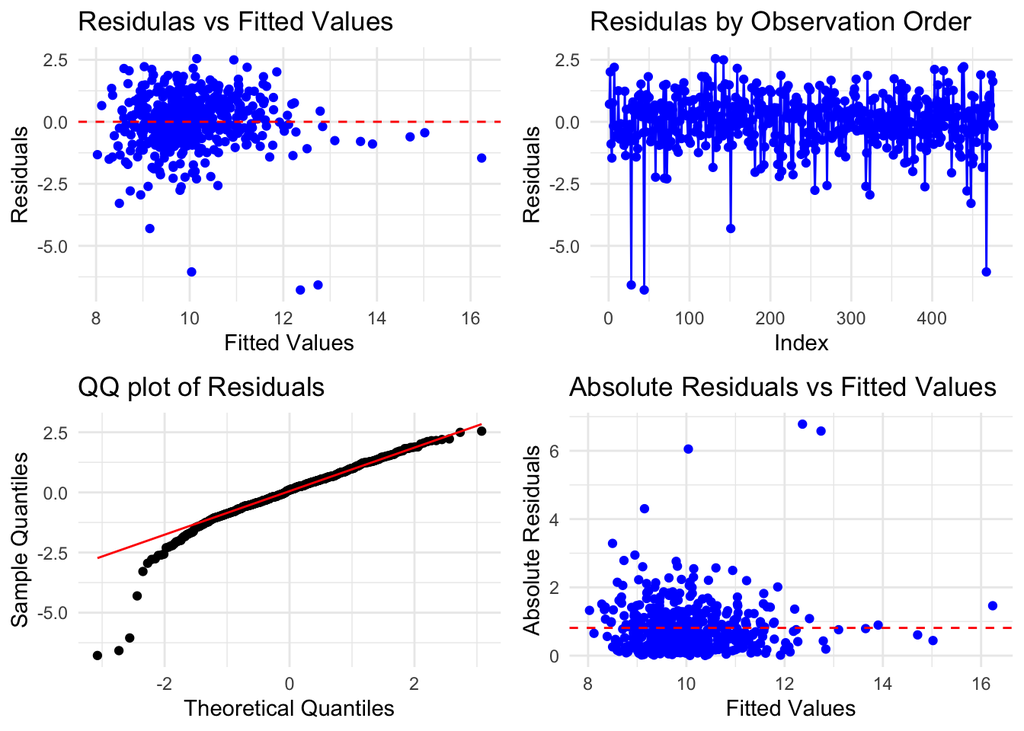

Figure 9: Linear model assumptions for 2023

*Checked assumption for the Fortune 2024 model*

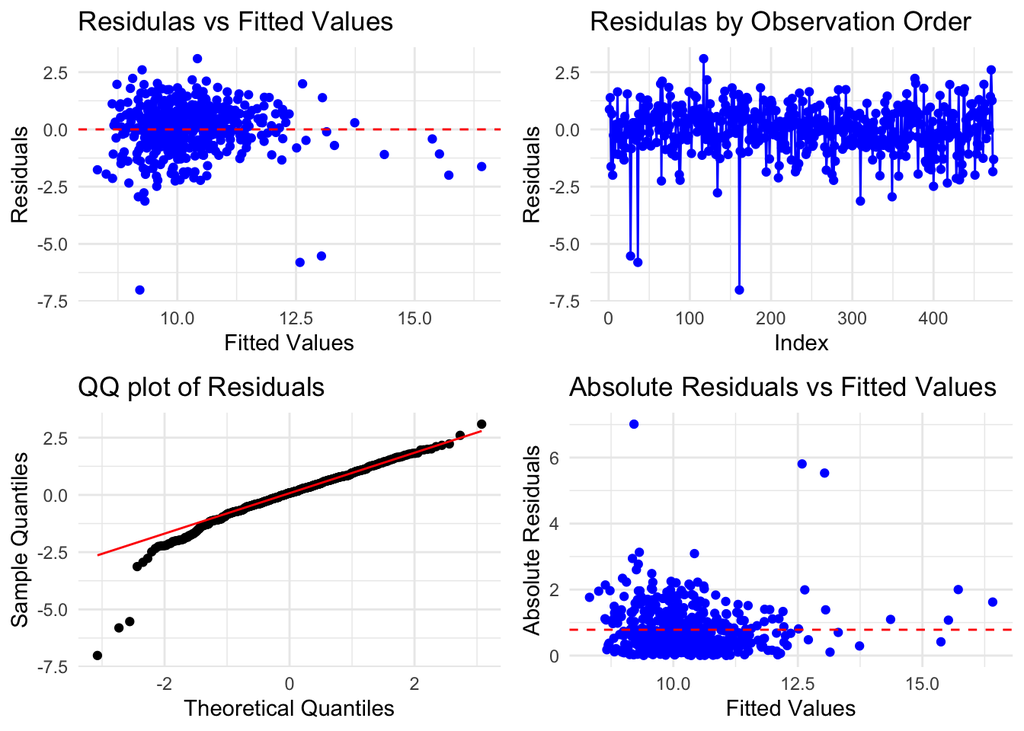

Figure 10: Linear model assumptions for 2024

*Predicted value*

Assuming the model is trustworthy we want to calculate the expected market value of a company in the quaternary sector with 100,000 employees, revenue of 100 000 USD millions, a loss of 5000 USD millions and assets of 50 000 USD millions. The following prediction is based on 90% prediction intervals. As a result, the predicted market value of such company is around 32 710 USD millions, within 90% prediction interval that true value will fall between 5010 and 213 557 USD millions. Prediction interval suggests much broader range, which can be due to a higher uncertainty and variability related to a number of predictors. See Table 6

Table 6: Expected Market Value of the Company

| Columns | Value |
| --- | --- |
| Expected Market Value (USD millions) | 32710.45 |
| Lower Bound (USD millions) | 5010.26 |
| Upper Bound (USD millions) | 213557.20 |

# Discussion and Conclusions

Linear model demonstrated reasonable significance with adjusted R-squared values of 0.4423 for 2023 year and 0.4728 for 2024 year. This suggests that the model explains approximately 44% and 47% of the variance in the log of MarketCap for 2023 and 2024 years respectfully.

Predicted estimate of Market Value of a company with certain parameters had been provided with a very broad prediction interval. This suggests significant uncertainty that can be connected to variability of predictors or that Market Value can be influenced by other predictors, that have not been captured by the linear model. Overall, given the limitations of fitted model, we recommend to explore other factors and their associations with the Market Value to fit a better model with more precise predictions.